# Reproducible Research: Assignment 2

Amin

Wednesday, October 21, 2015

# Synopsis

This is the report for the peer assignemt 2 of the course of Reproducible Research on Coursera. The aim of this assignment is to explore the U.S. National Oceanic and Atmospheric Administration’s (NOAA) storm database to answer some questions related to health and economic consequences.

# Global Setting

Here is the global setting for the code used throughout the report.

```r
echo = TRUE
library(plyr)
```

# Data Processing

## Loading the Data

The data is in the form of a comma-separated-value file compressed via the bzip2 algorithm . The data is available in [this link](https://d396qusza40orc.cloudfront.net/repdata%2Fdata%2FStormData.csv.bz2). A documentation for this dataset can be found at [this link](https://d396qusza40orc.cloudfront.net/repdata%2Fpeer2_doc%2Fpd01016005curr.pdf).

```r
setwd("C:/Amin/Coursera/RepData_PeerAssessment2/")
if (!"stormData" %in% ls()) {
  stormData <- read.csv(bzfile("repdata-data-StormData.csv.bz2"))
  }
head(stormData, n=2)
```

```
##   STATE__          BGN_DATE BGN_TIME TIME_ZONE COUNTY COUNTYNAME STATE
## 1       1 4/18/1950 0:00:00     0130       CST     97     MOBILE    AL
## 2       1 4/18/1950 0:00:00     0145       CST      3    BALDWIN    AL
##    EVTYPE BGN_RANGE BGN_AZI BGN_LOCATI END_DATE END_TIME COUNTY_END
## 1 TORNADO         0                                               0
## 2 TORNADO         0                                               0
##   COUNTYENDN END_RANGE END_AZI END_LOCATI LENGTH WIDTH F MAG FATALITIES
## 1         NA         0                        14   100 3   0          0
## 2         NA         0                         2   150 2   0          0
##   INJURIES PROPDMG PROPDMGEXP CROPDMG CROPDMGEXP WFO STATEOFFIC ZONENAMES
## 1       15    25.0          K       0
## 2        0     2.5          K       0
##   LATITUDE LONGITUDE LATITUDE_E LONGITUDE_ REMARKS REFNUM
## 1     3040      8812       3051       8806              1
## 2     3042      8755          0          0              2
```

## Most harmful events on poulation health

The goal of this section is to answer this question: across United States, which type of events are most harmful with respect to population health. There are two columns in the datasets called “FATALITIES” and “INJURIES” that are related to the population health. We calculate the sum of these two variables for every value of the event type.

```r
healthData = aggregate(cbind(FATALITIES,INJURIES) ~EVTYPE, data=stormData, FUN=sum)
head(healthData, n=2)
```

```
##                  EVTYPE FATALITIES INJURIES
## 1    HIGH SURF ADVISORY          0        0
## 2         COASTAL FLOOD          0        0
```

We add a new column to the data frame as “ALLDAMAGE” which is the sum of “FATALITIES” and “INJURIES”.

```r
healthData <- mutate(healthData, ALLDAMAGE=FATALITIES+INJURIES)
head(healthData, n=2)
```

```
##                  EVTYPE FATALITIES INJURIES ALLDAMAGE
## 1    HIGH SURF ADVISORY          0        0         0
## 2         COASTAL FLOOD          0        0         0
```

Now, to figure out what event type had most harm we order the data frame by diffierent columns.

```r
mostFatal <- healthData[with(healthData, order(-FATALITIES)),]
head(mostFatal)
```

```
##             EVTYPE FATALITIES INJURIES ALLDAMAGE
## 834        TORNADO       5633    91346     96979
## 130 EXCESSIVE HEAT       1903     6525      8428
## 153    FLASH FLOOD        978     1777      2755
## 275           HEAT        937     2100      3037
## 464      LIGHTNING        816     5230      6046
## 856      TSTM WIND        504     6957      7461
```

```r
mostInjury <- healthData[with(healthData, order(-INJURIES)),]
head(mostInjury)
```

```
##             EVTYPE FATALITIES INJURIES ALLDAMAGE
## 834        TORNADO       5633    91346     96979
## 856      TSTM WIND        504     6957      7461
## 170          FLOOD        470     6789      7259
## 130 EXCESSIVE HEAT       1903     6525      8428
## 464      LIGHTNING        816     5230      6046
## 275           HEAT        937     2100      3037
```

```r
mostAll <- healthData[with(healthData, order(-ALLDAMAGE)),]
head(mostAll)
```

```
##             EVTYPE FATALITIES INJURIES ALLDAMAGE
## 834        TORNADO       5633    91346     96979
## 130 EXCESSIVE HEAT       1903     6525      8428
## 856      TSTM WIND        504     6957      7461
## 170          FLOOD        470     6789      7259
## 464      LIGHTNING        816     5230      6046
## 275           HEAT        937     2100      3037
```

## The EVentes with the Greatest Economic Consequences

The goal of this section is to answer this question: across the United States, which types of events have the greatest economic consequences? There are four columns in the datasets related to the economic consequences: “PROPDMG”, “PROPDMGEX”, “CROPDMG” and “CROPDMGEXP”. We use the values “PROPDMGEX” and “CROPDMG” as described in the codebook to calculate the real values of proerty and crop damage. These new values are saved as two new columns called “PropertyDamage” and “CropDamage”.

```r
stormData <- mutate(stormData, PropertyDamage = (PROPDMGEXP=="H")*PROPDMG*100+(PROPDMGEXP=="K")*PROPDMG*1000+(PROPDMGEXP=="M")*PROPDMG*1000000+(PROPDMGEXP=="B")*PROPDMG*1000000000)
stormData <- mutate(stormData, CropDamage = (CROPDMGEXP=="H")*CROPDMG*100+(CROPDMGEXP=="K")*CROPDMG*1000+(CROPDMGEXP=="M")*CROPDMG*1000000+(CROPDMGEXP=="B")*CROPDMG*1000000000)
head(stormData, n=2)
```

```
##   STATE__          BGN_DATE BGN_TIME TIME_ZONE COUNTY COUNTYNAME STATE
## 1       1 4/18/1950 0:00:00     0130       CST     97     MOBILE    AL
## 2       1 4/18/1950 0:00:00     0145       CST      3    BALDWIN    AL
##    EVTYPE BGN_RANGE BGN_AZI BGN_LOCATI END_DATE END_TIME COUNTY_END
## 1 TORNADO         0                                               0
## 2 TORNADO         0                                               0
##   COUNTYENDN END_RANGE END_AZI END_LOCATI LENGTH WIDTH F MAG FATALITIES
## 1         NA         0                        14   100 3   0          0
## 2         NA         0                         2   150 2   0          0
##   INJURIES PROPDMG PROPDMGEXP CROPDMG CROPDMGEXP WFO STATEOFFIC ZONENAMES
## 1       15    25.0          K       0
## 2        0     2.5          K       0
##   LATITUDE LONGITUDE LATITUDE_E LONGITUDE_ REMARKS REFNUM PropertyDamage
## 1     3040      8812       3051       8806              1          25000
## 2     3042      8755          0          0              2           2500
##   CropDamage
## 1          0
## 2          0
```

Now, we calculate the sum of damages for every event type.

```r
damageData <- aggregate(cbind(PropertyDamage,CropDamage) ~EVTYPE, data=stormData, FUN=sum)
damageData <- mutate(damageData, AllDamage=PropertyDamage+CropDamage)
head(damageData, n=2)
```

```
##                  EVTYPE PropertyDamage CropDamage AllDamage
## 1    HIGH SURF ADVISORY          2e+05          0     2e+05
## 2         COASTAL FLOOD          0e+00          0     0e+00
```

Now, to figure out what type of event has most economic consequences, we order the data by diffierent columns.

```r
mostPropDmg <- damageData[with(damageData, order(-PropertyDamage)),]
head(mostPropDmg)
```

```
##                EVTYPE PropertyDamage CropDamage    AllDamage
## 170             FLOOD   144657709800 5661968450 150319678250
## 411 HURRICANE/TYPHOON    69305840000 2607872800  71913712800
## 834           TORNADO    56925660480  414953110  57340613590
## 670       STORM SURGE    43323536000       5000  43323541000
## 153       FLASH FLOOD    16140811510 1421317100  17562128610
## 244              HAIL    15727367220 3025537450  18752904670
```

```r
mostCropDmg <- damageData[with(damageData, order(-CropDamage)),]
head(mostCropDmg)
```

```
##          EVTYPE PropertyDamage  CropDamage    AllDamage
## 95      DROUGHT     1046106000 13972566000  15018672000
## 170       FLOOD   144657709800  5661968450 150319678250
## 590 RIVER FLOOD     5118945500  5029459000  10148404500
## 427   ICE STORM     3944927810  5022113500   8967041310
## 244        HAIL    15727367220  3025537450  18752904670
## 402   HURRICANE    11868319010  2741910000  14610229010
```

```r
mostAllDmg <- damageData[with(damageData, order(-AllDamage)),]
head(mostAllDmg)
```

```
##                EVTYPE PropertyDamage CropDamage    AllDamage
## 170             FLOOD   144657709800 5661968450 150319678250
## 411 HURRICANE/TYPHOON    69305840000 2607872800  71913712800
## 834           TORNADO    56925660480  414953110  57340613590
## 670       STORM SURGE    43323536000       5000  43323541000
## 244              HAIL    15727367220 3025537450  18752904670
## 153       FLASH FLOOD    16140811510 1421317100  17562128610
```

# Result

Here is the result for the events with most harm on the population health.

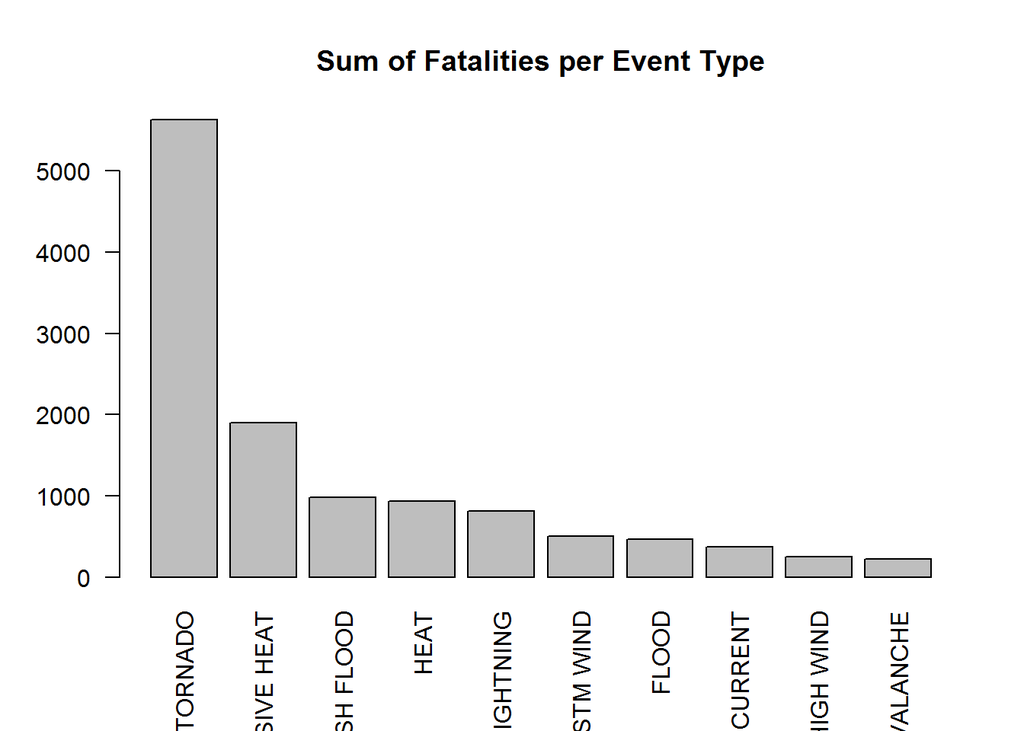

```r
barplot(mostFatal$FATALITIES[1:10],names.arg = mostFatal$EVTYPE[1:10],las=2,main="Sum of Fatalities per Event Type")
```

[figure not shown]

```r
barplot(mostInjury$INJURIES[1:10],names.arg = mostFatal$EVTYPE[1:10],las=2,main="Sum of Injuries per Event Type")
```

[figure not shown]

```r
barplot(mostAll$ALLDAMAGE[1:10],names.arg = mostFatal$EVTYPE[1:10],las=2,main="Sum of all Human Health Damages per Event Type")
```

According to the results, the “TORNADO” has the highest “FATALITIES”, “INJURIES” and the sum of the two. So, “TORNADO” is the most harmful type of event for the population health.

Here is the result for the events with most economic consequences.

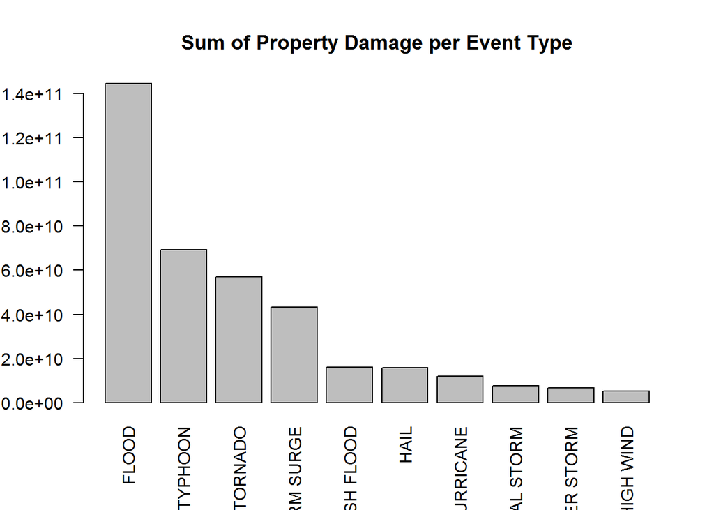

```r
barplot(mostPropDmg$PropertyDamage[1:10],names.arg = mostPropDmg$EVTYPE[1:10],las=2,main="Sum of Property Damage per Event Type")
```

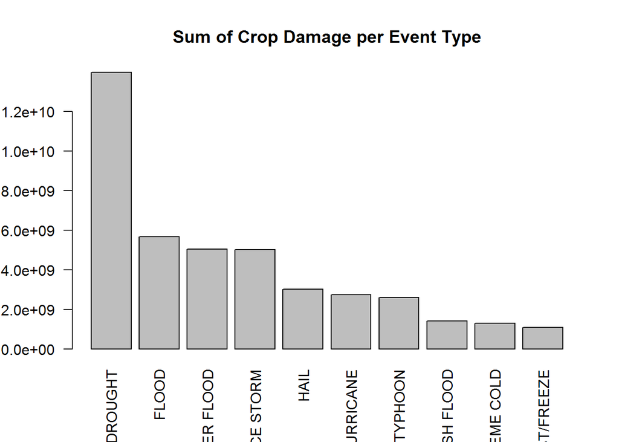

```r
barplot(mostCropDmg$CropDamage[1:10],names.arg = mostCropDmg$EVTYPE[1:10],las=2,main="Sum of Crop Damage per Event Type")
```

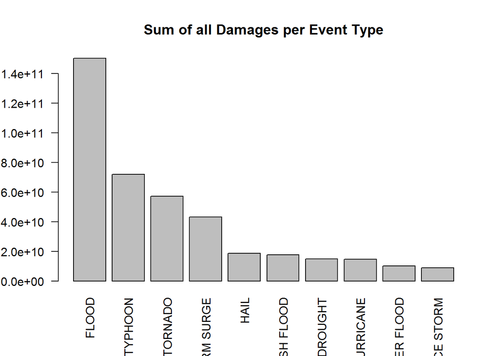

```r
barplot(mostAllDmg$AllDamage[1:10],names.arg = mostAllDmg$EVTYPE[1:10],las=2,main="Sum of all Damages per Event Type")
```

According to the results, the “FLOOD” has the highest damage on the properties, and “DROUGHT” has the highest damage on the crops. Overally, the “FLOOD” has the highest economic impact.